# Clean Beauty Recommender: Skincare & Makeup for Every Shade

Sheriann McLarty

2025-07-03

# 1 Introduction

The beauty industry loves to say “universal,” but that often only includes a narrow range of skin tones. Many Black women—and people with medium to deep complexions—struggle to find clean, effective skincare and makeup that actually *shows up* on their skin. The clean beauty space especially lacks representation, leaving consumers with unsafe ingredients, inadequate shade ranges, and false marketing.

This project builds a recommender system that centers **melanin-rich users**—without excluding those with fairer skin. We show how product performance and preferences differ between users of different complexions, and we build tools that help *everyone* find products that work for them.

**[Project 1 GitHub](https://github.com/sheriannmclarty/data612_recommender_systems/tree/Project-1)**  
**[Project 2 GitHub](https://github.com/sheriannmclarty/data612_recommender_systems/tree/Project-2)**

# 2 Data Preview: Understanding Our Raw Materials

**Why:** To ensure we’re working with the right information and to highlight the key data points used in our analysis. **What:** A quick look at the structure and content of our filtered dataset, showcasing relevant columns like user ID, skin tone, product, and review text.

```r
df <- read_csv("filtered_skintone_reviews_r.csv")
df %>%
  select(User = author_id,
         Skin_Tone = skin_tone,
         Skin_Type = skin_type,
         Product = product_name_x,
         Brand = brand_name_x,
         Rating = rating_x,
         Review = review_text) %>%
  mutate(Review = str_trunc(Review, 80)) %>%
  head(5) %>%
  kable()
```

| User | Skin_Tone | Skin_Type | Product | Brand | Rating | Review |
| --- | --- | --- | --- | --- | --- | --- |
| 23866342710 | fairLight | combination | Retinol Anti-Aging Serum | The INKEY List | 1 | Why, why, why would you change the formula?!!! I have been using this for yea… |
| 5683470893 | light | combination | Retinol Anti-Aging Serum | The INKEY List | 1 | This a a wall of text but I genuinely have to put this out there.I LOVED this… |
| 5117068738 | light | normal | Retinol Anti-Aging Serum | The INKEY List | 5 | Holy guacamole….I bought this about a month ago and held off on using it be… |
| 21582452079 | fairLight | normal | Retinol Anti-Aging Serum | The INKEY List | 1 | I’m writing this because of the overwhelmingly positive reviews, but I had an… |
| 1342721722 | fair | combination | Retinol Anti-Aging Serum | The INKEY List | 4 | I have used a number of products over the years that were supposed to have re… |

# 3 Skin Tone Breakdown: Who’s Represented?

**Why:** Before building inclusive models, it’s critical to understand the demographic distribution of our users. Do we have enough voices from melanin-rich consumers? **What:** This section visualizes the count of reviews across different skin tone categories in our dataset.

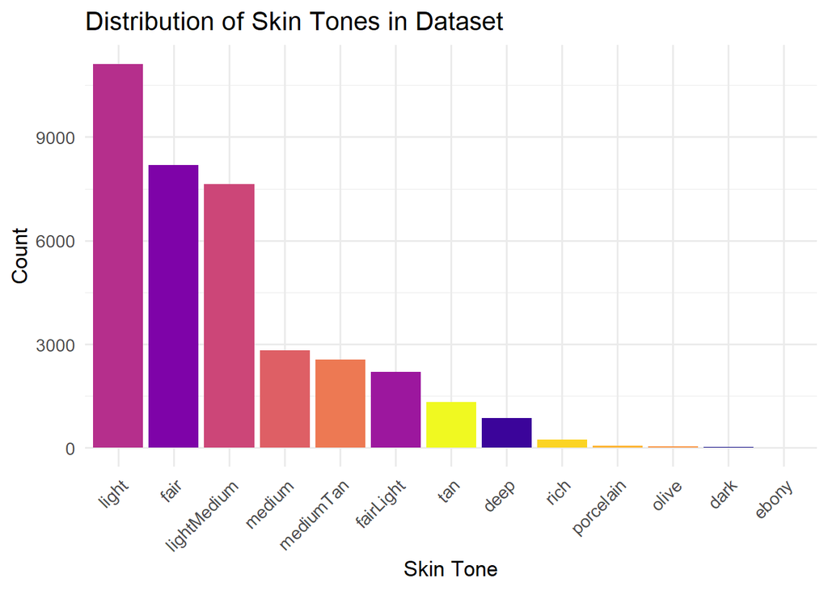

| skin_tone | n |
| --- | --- |
| light | 11108 |
| fair | 8187 |
| lightMedium | 7636 |
| medium | 2817 |
| mediumTan | 2559 |
| fairLight | 2206 |
| tan | 1320 |
| deep | 861 |
| rich | 241 |
| porcelain | 61 |
| olive | 50 |
| dark | 19 |
| ebony | 1 |

```r
df %>%
  filter(!str_detect(skin_tone, "^[0-9]+$")) %>%
  count(skin_tone) %>%
  mutate(skin_tone = fct_lump(factor(skin_tone), n = 15)) %>%
  ggplot(aes(reorder(skin_tone, -n), n, fill = skin_tone)) +
  geom_col(show.legend = FALSE) +
  labs(title = "Distribution of Skin Tones in Dataset",
       x = "Skin Tone", y = "Count") +
  scale_fill_viridis_d(option = "C") +
  theme_minimal(base_size = 13) +
  theme(axis.text.x = element_text(angle = 45, hjust = 1))
```

**Interpretation:** While light and fair tones dominate (e.g., 11,108 light reviews, 8,187 fair), we still have meaningful representation from users labeled “medium” (2,817), “tan” (1,320), and “deep” (861). That’s crucial—without diverse voices, no system can claim to be inclusive.

# 4 Sentiment by Skin Tone: Do “Universal” Claims Hold Up?

**Why:** To empirically test the beauty industry’s claim of “universal” shades by analyzing how product sentiment differs across various skin tones. **What:** We use sentiment analysis (specifically the Bing lexicon) to assign a positive/negative ratio to reviews, revealing user experience disparities.

### 4.0.1 What is a sentiment score?

Sentiment analysis identifies whether text is positive or negative. We’re using the “Bing” lexicon to assign scores to each review. A higher ratio of positive to negative words implies a more favorable product experience.

```r
df_sent <- df %>%
  unnest_tokens(word, review_text) %>%
  inner_join(get_sentiments("bing"))
```

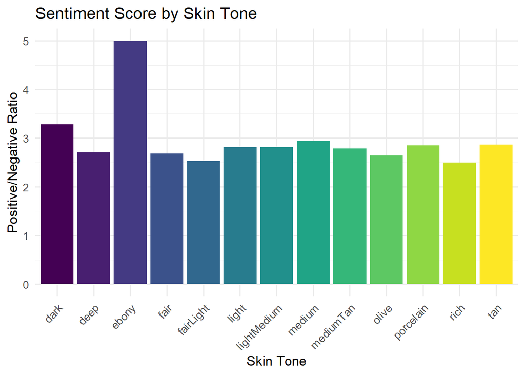

```r
df_sent %>%
  group_by(skin_tone, sentiment) %>%
  tally() %>%
  spread(sentiment, n, fill = 0) %>%
  mutate(ratio = positive / (negative + 1)) %>%
  filter(!str_detect(skin_tone, "^[0-9]+$")) %>%
  ggplot(aes(x = skin_tone, y = ratio, fill = skin_tone)) +
  geom_col(show.legend = FALSE) +
  labs(title = "Sentiment Score by Skin Tone",
       y = "Positive/Negative Ratio", x = "Skin Tone") +
  scale_fill_viridis_d(option = "D") +
  theme_minimal(base_size = 13) +
  theme(axis.text.x = element_text(angle = 45, hjust = 1))
```

# 5 Create Rating Matrix: Preparing Data for the Models

**Why:** To transform our raw review data into a structured format that the `recommenderlab` package can efficiently process for building our recommendation engines. **What:** Conversion of our user, item, and rating data into a `realRatingMatrix`, an essential input for collaborative filtering algorithms.

```r
cb_df_clean <- df %>%
  select(user = author_id, item = product_name_x, rating = rating_x) %>%
  filter(!is.na(user), !is.na(item), !is.na(rating)) %>%
  mutate(user = as.factor(user), item = as.factor(item))

cb_matrix <- as(cb_df_clean, "realRatingMatrix")
```

# 6 What’s a Recommender System?

**Why:** To empower consumers with personalized product discovery, cutting through marketing noise and ensuring products truly meet individual needs. **Who:** Consumers seeking tailored product suggestions based on their unique preferences, skin type, and tone.

> Think Netflix—but for your face.

Recommender systems suggest items based on what you (or people like you) like. In the beauty space, this means: - Suggesting blushes that actually show up on darker skin - Filtering out products with harmful ingredients - Recommending items based on your skin type, tone, and preferences

**Why:** To quantitatively assess the performance of our Item-Based (IBCF) and User-Based (UBCF) collaborative filtering models and understand their respective strengths and weaknesses. **What:** We use RMSE (Root Mean Square Error) as our primary metric to compare prediction accuracy, with lower RMSE indicating better model performance.

```r
e <- evaluationScheme(cb_matrix, method = "split", train = 0.8, given = 3)
cb_eval <- Recommender(getData(e, "train"), method = "IBCF")
cb_pred <- predict(cb_eval, getData(e, "known"), type = "ratings")
error_cb <- calcPredictionAccuracy(cb_pred, getData(e, "unknown"))

cf_eval <- Recommender(getData(e, "train"), method = "UBCF")
cf_pred <- predict(cf_eval, getData(e, "known"), type = "ratings")
error_cf <- calcPredictionAccuracy(cf_pred, getData(e, "unknown"))

error_df <- bind_rows(
  as_tibble(error_cb) %>% mutate(method = "Item-Based CF"),
  as_tibble(error_cf) %>% mutate(method = "User-User CF")
)

kable(error_df)
```

| value | method |
| --- | --- |
| 0.6774115 | Item-Based CF |
| 0.4588864 | Item-Based CF |
| 0.2538056 | Item-Based CF |
| 0.7362195 | User-User CF |
| 0.5420191 | User-User CF |
| 0.3733405 | User-User CF |

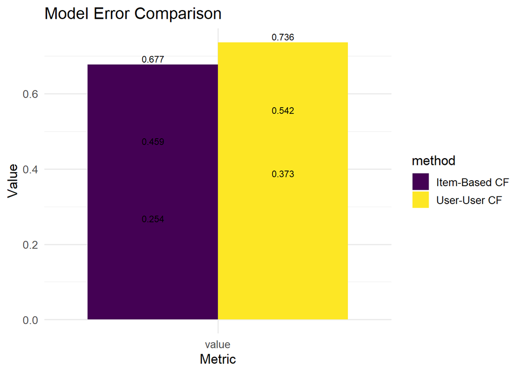

```r
error_df %>%
  pivot_longer(cols = -method) %>%
  ggplot(aes(x = name, y = value, fill = method)) +
  geom_col(position = "dodge") +
  geom_text(aes(label = round(value, 3)), position = position_dodge(width = 0.9), vjust = -0.3, size = 3) +
  labs(title = "Model Error Comparison",
       x = "Metric", y = "Value") +
  scale_fill_viridis_d() +
  theme_minimal(base_size = 13)
```

Why both models matter:

UBCF is your personal shopper—it finds people like you and suggests what they love. IBCF is your product whisperer—it helps you explore related items that align with your taste. Together, they give us a powerful hybrid lens. That’s how we bridge the representation gap: by combining personalization and discovery to serve every shade and skin type with care.

# 7 Who Benefits? Real-World Examples of Personalized Beauty

**Rae:** Medium skin, oily, prefers fragrance-free and lightweight moisturizers.

**Blair:** Deep skin, dry, wants pigment-rich blushes and products that work well with SPF.

This recommender system is a powerful first step toward personalized, inclusive beauty tech. Consumers of color—especially those with deeper skin tones—stand to gain the most, as they have long been underserved by generic recommendations and exclusionary product lines. Our findings highlight the urgent need for brands to go beyond “universal” claims and invest in meaningful representation.

**Future Work:** - Integrate content-based filtering using product ingredients and safety tags - Expand the dataset to include more makeup categories (foundations, lipsticks, etc.) - Build a skin tone classifier or embed user images (ethically!) to recommend based on actual undertones and hues - Introduce explainable AI techniques to show *why* each product was recommended - Collect user feedback to improve model tuning and boost trust

Together, these improvements can drive forward a new standard for clean beauty: one where every complexion is not only seen, but supported.

# 8 References

- Bing Sentiment Lexicon via tidytext: https://www.tidytextmining.com
- recommenderlab R package: https://cran.r-project.org/web/packages/recommenderlab/
- Treemapify R package: https://cran.r-project.org/web/packages/treemapify/
- Clean Beauty Product Data (scraped from a major beauty retailer)
- Inspiration from Stanford’s Networks Illustrated (Parts K–P)